# Grades

Krishna Kalyan

1/16/2017

We were give grades data set and lets load it up in R.

```r
rm(list=ls())
setwd('/Users/krishna/Downloads/exam/param')
load('Grades.Rdata')
Grades <- data.frame(Grades)
```

We begin by doing a summary on our dataset to understand the data better.

```r
dim(Grades)
```

```
## [1] 200   2
```

```r
summary(Grades)
```

```
##       sat            gpa
##  Min.   : 720   Min.   :0.790
##  1st Qu.:1048   1st Qu.:1.965
##  Median :1140   Median :2.335
##  Mean   :1135   Mean   :2.319
##  3rd Qu.:1240   3rd Qu.:2.683
##  Max.   :1550   Max.   :3.840
```

We would also like to see the distribution of our dataset.

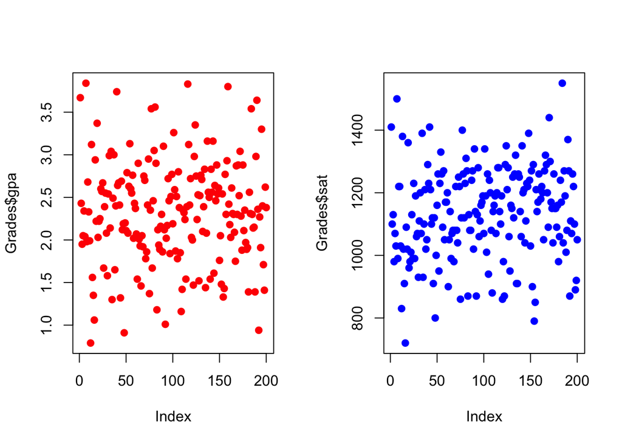

```r
par(mfrow=c(1,2))
plot(Grades$gpa, col='red', pch=19)
plot(Grades$sat, col='blue', pch=19)
```

We observe that the dataset are randomly distributed. It would not make sense transforming it.

1. Scatter plot and observation

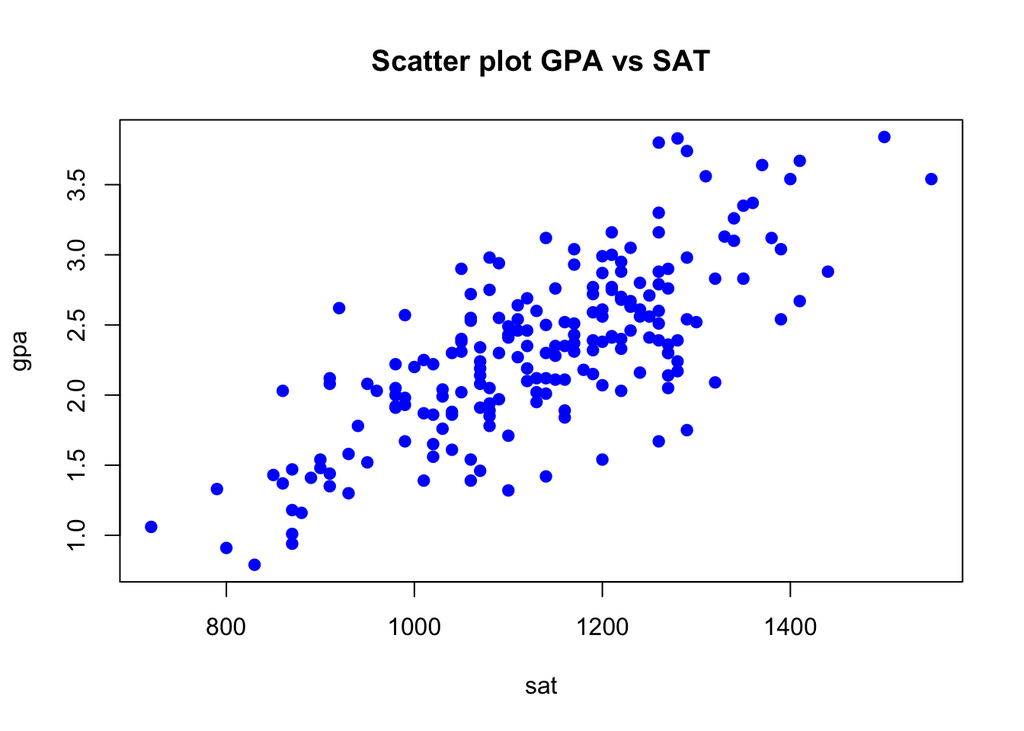

```r
par(mfrow=c(1,1))
plot(Grades,col='blue', pch=19, main='Scatter plot GPA vs SAT')
```

We observe that our data has a linear positive trend. We can also observe that there are few extreme points. Knowing this like to know the correlation value and also create a box plots for my observations.

```r
par(mfrow=c(1,2))
model1 <- lm(gpa~sat, data=Grades)
summary(model1)
```

```
##
## Call:
## lm(formula = gpa ~ sat, data = Grades)
##
## Residuals:
##      Min       1Q   Median       3Q      Max
## -1.04954 -0.25960 -0.00655  0.26044  1.09328
##
## Coefficients:
##               Estimate Std. Error t value Pr(>|t|)
## (Intercept) -1.1920638  0.2224502  -5.359 2.32e-07 ***
## sat          0.0030943  0.0001945  15.912  < 2e-16 ***
## ---
## Signif. codes:  0 '***' 0.001 '**' 0.01 '*' 0.05 '.' 0.1 ' ' 1
##
## Residual standard error: 0.3994 on 198 degrees of freedom
## Multiple R-squared:  0.5612, Adjusted R-squared:  0.5589
## F-statistic: 253.2 on 1 and 198 DF,  p-value: < 2.2e-16
```

```r
cor(Grades)
```

```
##           sat       gpa
## sat 1.0000000 0.7491015
## gpa 0.7491015 1.0000000
```

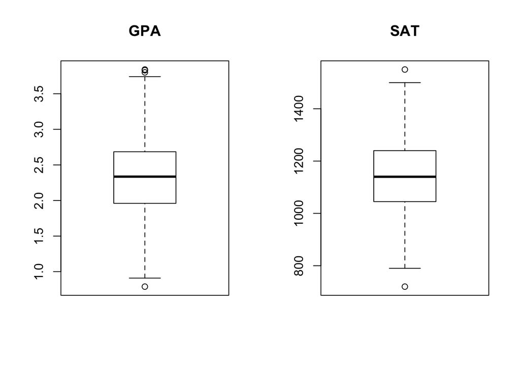

```r
boxplot(Grades$gpa, main='GPA')
boxplot(Grades$sat, main='SAT')
```

We can say that our data is positively correlated $0.74$. I think this is in the higher side. Also with the box plots, I observe that GPA has more outlier values.

2. Model used with hyphothesis. Based on the patterns observed in my data I see that there is a linear relationship between my response and predictors. I will use a `Linear Model` to analyse this data. I will model my respone $GPA$ as a function of my predictor $SAT$. This can be also expressed as below. $GPA ~ SAT$

```r
model_lm <- lm(gpa~sat, data=Grades)
summary(model_lm)
```

```
##
## Call:
## lm(formula = gpa ~ sat, data = Grades)
##
## Residuals:
##      Min       1Q   Median       3Q      Max
## -1.04954 -0.25960 -0.00655  0.26044  1.09328
##
## Coefficients:
##               Estimate Std. Error t value Pr(>|t|)
## (Intercept) -1.1920638  0.2224502  -5.359 2.32e-07 ***
## sat          0.0030943  0.0001945  15.912  < 2e-16 ***
## ---
## Signif. codes:  0 '***' 0.001 '**' 0.01 '*' 0.05 '.' 0.1 ' ' 1
##
## Residual standard error: 0.3994 on 198 degrees of freedom
## Multiple R-squared:  0.5612, Adjusted R-squared:  0.5589
## F-statistic: 253.2 on 1 and 198 DF,  p-value: < 2.2e-16
```

Based on the summary of the model, I conclude that it is not a very good model as I observe an $R^2$ of $0.56$ and see that $sat$ is a significant variable in my model with `p-value` less than $0.001$.

Ho : Our model fit the data well H1 : Model does not represnt the data

We reject Ho as we see that the `p-value` is only $2.2e-16$ and see if we can improve this model.

3. Expected change in mean GPA when sat score inc by 50.

```r
gpa <- -1.192 + 0.003 * 50
gpa
```

```
## [1] -1.042
```

```r
# I am not sure of this answer above

# Or it could be 50 multiplied by it coefficient
50 * 0.003
```

```
## [1] 0.15
```

4. Coeffieceint of sat.

```r
model_lm$coefficients[2]
```

```
##        sat
## 0.00309427
```

5. Interpretation of Residual standard error.

Residual standard error is exactly 0 then the model fits the data perfectly. $0.3994$ tells me that we dont have a very good model. Residual can be calculated from the formual below. (y - yhat)

6. Intepret Multiple R square.

$0.5612$ is the value in the multiple R squared. Higher the value the better ($1$ is the best). We can say again here that we dont have a very good model. $R^2$ can be interpreted as the percentage of variance in the dependent variable that can be explained by the predictors.

7. Obtain confidence Intervals

```r
conf <- confint(model_lm,level = 0.95)
(conf)
```

```
##                    2.5 %       97.5 %
## (Intercept) -1.630739455 -0.753388169
## sat          0.002710782  0.003477759
```

8. Predicted Values

```r
values <- c(40, 152,196)
conf <- confint(model_lm,level = 0.95)
pred <- predict(model_lm, Grades)
pred[values]
```

```
##       40      152      196
## 2.799545 1.592779 2.582946
```

9. Check model with plots.

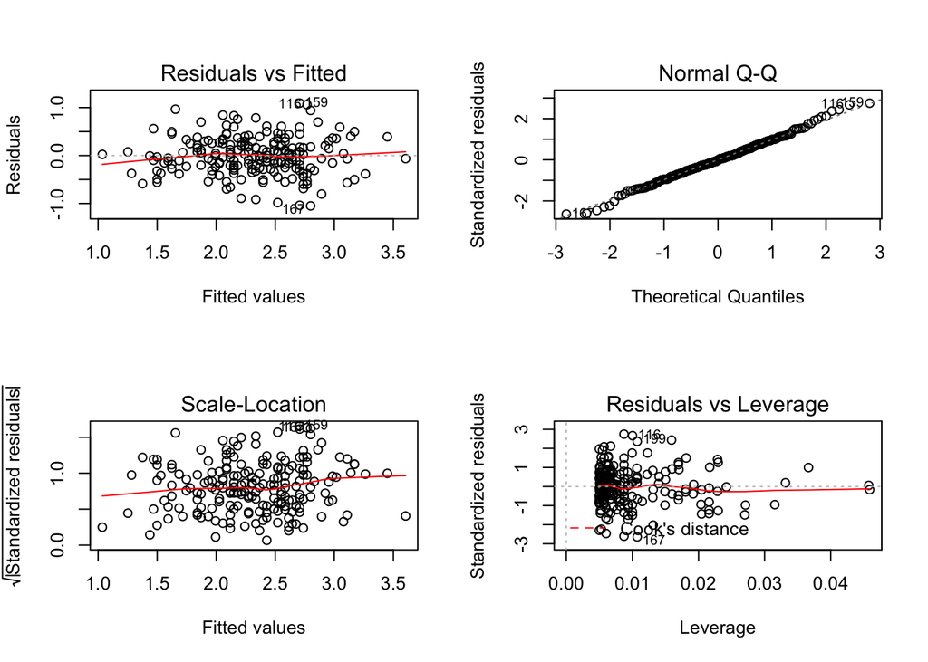

```r
par(mfrow=c(2,2))
plot(model_lm)
```